# Análisis Multivariado de Datos

Agrupamiento / Clustering

Mario José Pacheco López

2026-06-14

### Agrupamiento

El análisis de agrupamiento, conglomerados o *clustering*, es un conjunto de algoritmos, denominados como no supervisados, que permiten la segmentación, y por tanto el agrupamiento o clasificación, de conjuntos de individuos multivariados en grupos o clases mutuamente excluyentes que no existen previamente.

### Objetivo

Dentro de los objetivos de los métodos de agrupamiento está que los grupos resultantes sean lo más homogéneos dentro y lo más heterogéneos entre sí, por lo que se deben emplear métricas de homogeneidad/heterogeneidad (generalmente medidas de distancia) que garanticen que los grupos creados cumplan con estas características. Además, el proceso de agrupamiento debe incluir la determinación tanto del número de grupos a crear, así como la pertenencia de cada individuo a cada uno de esos grupos.

### Pasos

Un análisis de agrupamiento consta de los siguientes pasos:

1. Selección de una medida de distancia / disimilitud
2. Selección de un algoritmo de agrupamiento
3. Determinación del número óptimo de grupos
4. Evaluación de los grupos resultantes
5. *Caracterización de los grupos resultantes*

### Métodos

Existe una gran variedad de métodos de agrupamiento que dependen de la medida de distancia entre individuos o grupos

- Jerárquicos
- Basados en centroides
- Basados en densidades
- Basados en mezclas de distribuciones

### Medidas de Distancia

Considere una matriz de datos $\boldsymbol{X}$ de tamaño $n\times p$ con $n$ individuos y $p$ variables. Una medida de distancia/disimilaridad entre los individuos en $\boldsymbol{X}$ se puede expresar como una matriz de la forma:
$$D_{(n\times n)}=\left(\begin{array}{cccc}
d_{11} & d_{12} & \cdots & d_{1n}\\
d_{21} & d_{22} & \cdots & d_{2n}\\
\vdots & \vdots & \ddots & \vdots\\
d_{n1} & d_{n2} & \cdots & d_{nn}
\end{array}\right),$$
donde $d_{ii'}$ corresponde a la distancia/disimilaridad entre los individuos $i$ e $i'$ del conjunto de datos.

Generalmente, antes de calcular la distancia/disimilaridad entre dos individuos se debe realizar la “estandarización” de las variables para evitar el efecto de la escala de medida.

### Medidas de Distancia

**Variables numéricas**: distancia de Minkowski entre dos individuos $i$ e $i'$

$$d_{ii'}=\left\Vert x_{i}-x_{i'}\right\Vert _{a}=\left(\sum_{j=1}^{p}\left|x_{ij}-x_{i'j}\right|^{a}\right)^{1/a},$$
Se convierte en:

- distancia de Manhattan cuando $a=1$
- distancia Euclidiana cuando $a=2$

### Medidas de Distancia

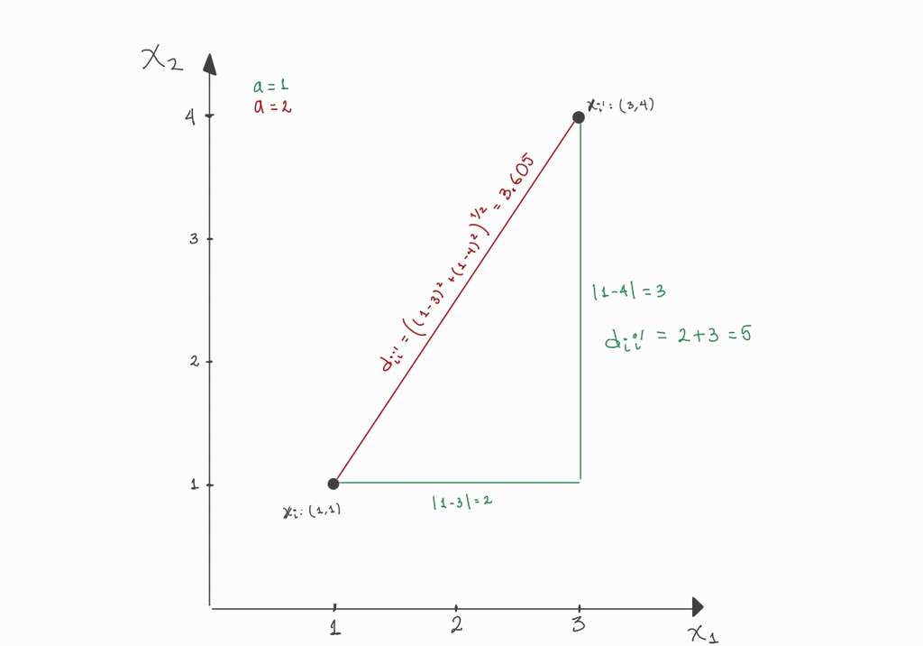

### Medidas de Distancia

**Variables binarias**: a partir de la matriz indicadora $\boldsymbol{Z}$, con elementos $Z_{ij} = 1$ si el individuo $i$ selecciona la categoría de interés o $Z_{ij} = 0$ en caso contrario ($i=1,2,...,n$, $j=1,2,...,p$), se definen las cantidades
$$\begin{aligned}
a_{1}&=\sum_{j=1}^{p}I\left\{ z_{ij}=z_{i'j}=1\right\}; \quad
a_{2}=\sum_{j=1}^{p}I\left\{ z_{ij}=z_{i'j}=0\right\}\\ b_{1}&=\sum_{j=1}^{p}I\left\{ z_{ij}=0,\ z_{i'j}=1\right\}; \quad b_{2}=\sum_{j=1}^{p}I\left\{ z_{ij}=1,\ z_{i'j}=0\right\}
\end{aligned}$$

### Medidas de Distancia

Se define la distancia entre dos individuos $i$ e $i'$ como
$$d_{ii'}=\frac{b_{1}+b_{2}}{a_{1}+b_{1}+b_{2}+\delta a_{2}}, \ \ \delta=0,1.$$

Se convierte en:

- Disimilitud de emparejamiento simple cuando $\delta=1$
- Disimilitud de Jaccard cuando $\delta=0$

### Medidas de Distancia

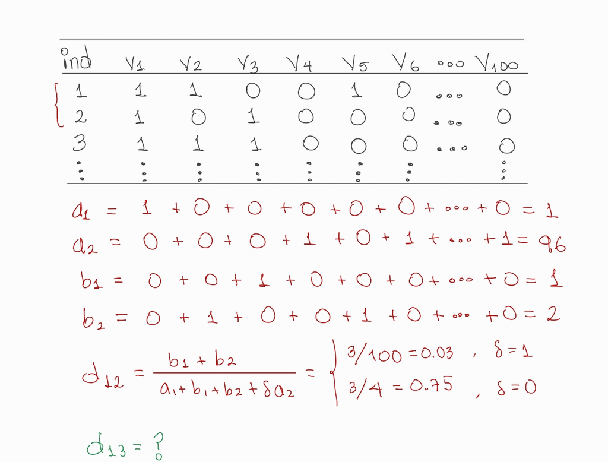

### Medidas de Distancia

**Variables categóricas**: en el caso de más de dos categorías de respuesta, calculamos la distancia entre dos individuos $i$ e $i'$ como
$$d_{ii'} = 1-\frac{1}{p}\sum^p_{j=1}I\left\{ x_{ij}=x_{i'j}\right\}.$$

### Medidas de Distancia

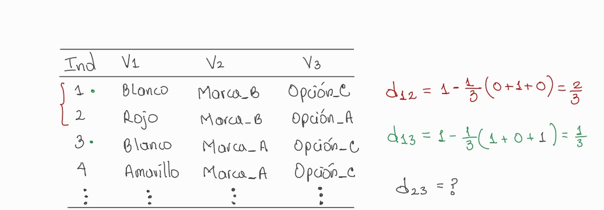

### Medidas de Distancia

**Variables ordinales**: usamos $r_{ij}$, el rango de la variable $j$ en el individuo $i$, y definimos la variable estandarizada $Z_j$ con elementos
$$z_{ij} = \frac{r_{ij}-1}{r_{(n)j}-1}.$$
Luego, la distancia entre el par de individuos $i$ e $i'$ se define como
$$d_{ii'} = \frac{1}{p}\sum^p_{j=1}\mid z_{ij}-z_{i'j} \mid.$$

### Medidas de Distancia

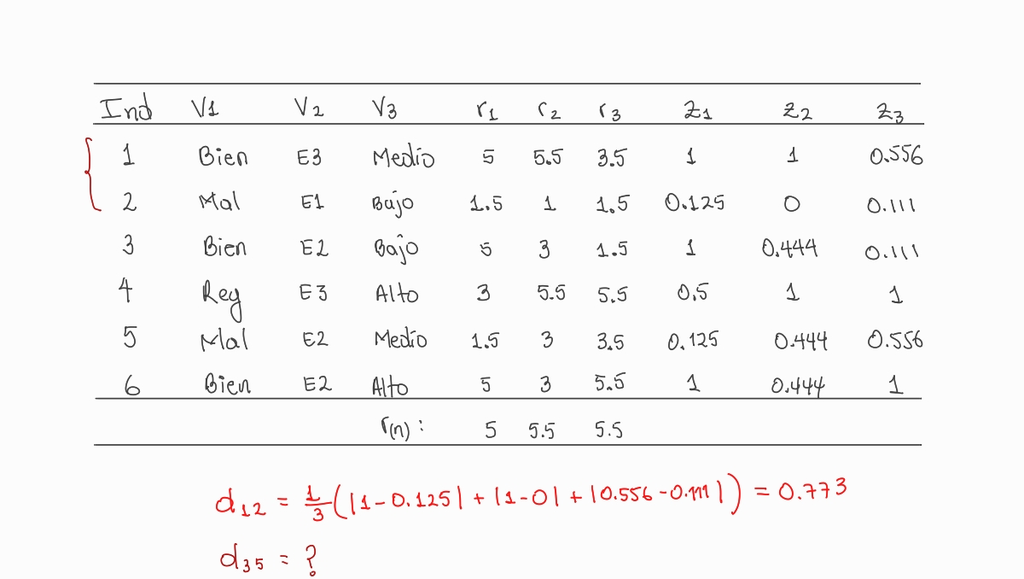

### Medidas de Distancia

**Mixtura de variables**: se define la distancia de Gower
$$d_{ii'}=1-\frac{\sum_{j=1}^{p}\delta_{ii'j}s_{ii'j}}{\sum_{j=1}^{p}\delta_{ii'j}},$$
donde $\delta_{ii'j} = 1$ si la variable $j$ es observada en ambos individuos y $\delta_{ii'j} = 0$ en caso contrario.

### Medidas de Distancia

En el caso de variables binarias
$$\begin{aligned}
s_{ii'j} &= I\{x_{ij}=x_{i'j}\} \quad \text{(simétricas)} \\[4pt]
s_{ii'j} &= I\{x_{ij}=x_{i'j}=1\} \quad \text{(asimétricas)}
\end{aligned}$$

En el caso de variables categóricas
$$s_{ii'j}=I\left\{ x_{ij}=x_{i'j}\right\}.$$

### Medidas de Distancia

En el caso de variables ordinales
$$s_{ii'j} = 1 - \mid z_{ij}-z_{i'j} \mid,$$
con $z_{ij}$ la estandarización de variables ordinales.

En caso de variables numéricas
$$s_{ii'j} = 1-\frac{\left|x_{ij}-x_{i'j}\right|}{x_{(n)j}-x_{(1)j}}.$$

### Medidas de Distancia

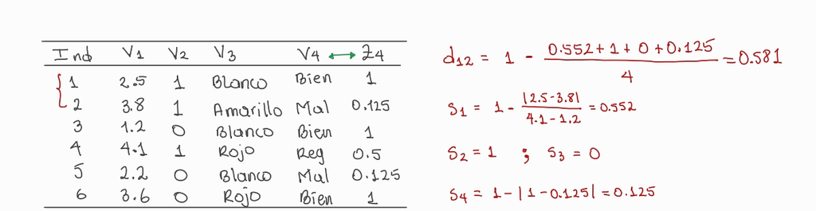

### Agrupamiento jerárquico

Características:

- Establecen una jerarquía en el agrupamiento basada en la distancia entre individuos
- Durante su implementación, no es necesario conocer de manera anticipada el número de grupos
- Tiene su propio gráfico (dendrograma) de representación del proceso de agrupamiento y de los grupos resultantes.

### Agrupamiento jerárquico

**Algoritmo aglomerativo**:

1. Construir la partición más fina de individuos, considerando a cada individuo como un grupo
2. Calcular la matriz de distancias entre grupos
3. Encontrar los grupos con menor distancia para formar un solo grupo
4. Calcular la distancia entre los nuevos grupos y obtener la matriz de distancias reducida
5. Repetir 3-4 hasta tener un solo grupo con todos los individuos

### Agrupamiento jerárquico

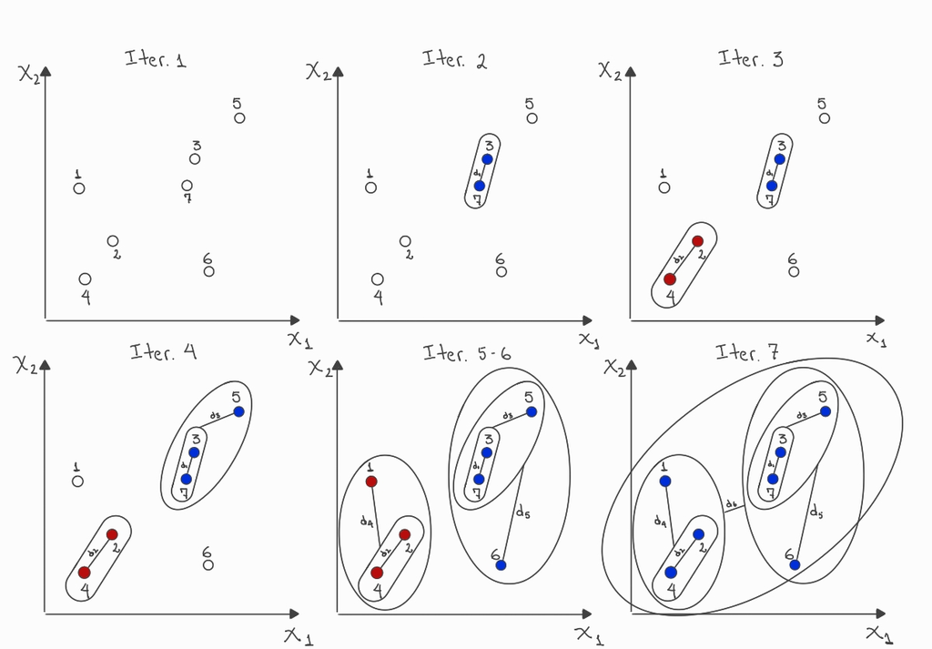

### Agrupamiento jerárquico

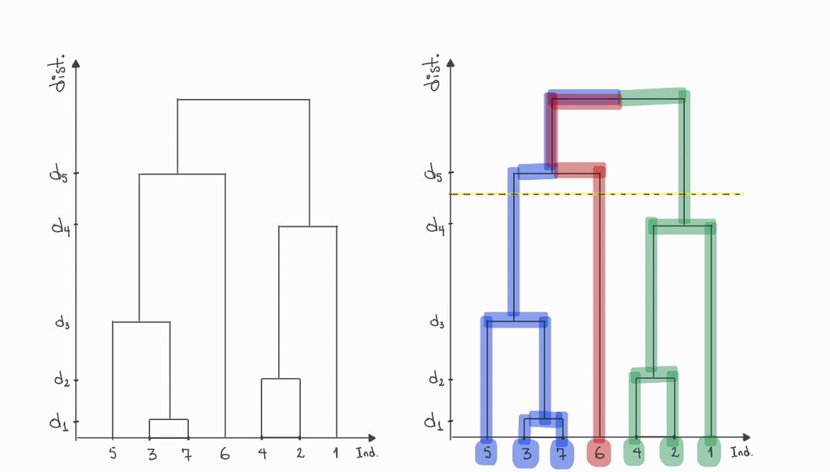

### Agrupamiento jerárquico

**Fórmula de *Lance-Williams*** : sean $\mathcal{A}$ y $\mathcal{B}$ los grupos con la menor distancia encontrados en el Paso 3 con los cuales se conforma el grupo $\mathcal{A}\cup \mathcal{B}$ y sea $\mathcal{C}$ cualquier otro grupo conformado por uno o más individuos en alguna iteración previa
$$d_{\left(\mathcal{A}\cup \mathcal{B}\right),\mathcal{C}} = \alpha_1 d_{\mathcal{A},\mathcal{C}} + \alpha_2 d_{\mathcal{B},\mathcal{C}} + \lambda d_{\mathcal{A},\mathcal{B}} + \gamma\mid d_{\mathcal{A},\mathcal{C}}-d_{\mathcal{B},\mathcal{C}} \mid$$
con $\alpha_1$, $\alpha_2$, $\lambda$ y $\gamma$ constantes.

### Agrupamiento jerárquico

- Si $\alpha_1=\alpha_2=1/2$, $\lambda=0$ y $\gamma=-1/2$ el método del vecino más cercano o del **enlace simple**
- Si $\alpha_1=\alpha_2=1/2$, $\lambda=0$ y $\gamma=1/2$ obtenemos el método del vecino más lejano o del **enlace completo**
- Si $\alpha_1=\alpha_2=1/2$ y $\lambda=\gamma=0$ se obtiene el método de **McQuitty**

### Agrupamiento jerárquico

- El método del **enlace promedio** escoge $\lambda=\gamma=0$ y
  $$\begin{aligned}
  \alpha_1 &= \frac{n_\mathcal{A}}{n_\mathcal{A}+n_\mathcal{B}}\\
  \alpha_2 &= \frac{n_\mathcal{B}}{n_\mathcal{A}+n_\mathcal{B}}
  \end{aligned}$$
- El método de la **mediana** escoge $\alpha_1=\alpha_2=1/2$ y $\lambda=-1/4$, $\gamma=0$ y
  $$d_{\mathcal{D},\mathcal{E}}=\left\Vert \boldsymbol{c}_{\mathcal{D}}-\boldsymbol{c}_\mathcal{E}\right\Vert^2_2$$

### Agrupamiento jerárquico

- El método del **centroide** escoge $\gamma=0$,
  $$\begin{aligned}
  \alpha_1 &= \frac{n_\mathcal{A}}{n_\mathcal{A}+n_\mathcal{B}}; \quad
  \alpha_2 = \frac{n_\mathcal{B}}{n_\mathcal{A}+n_\mathcal{B}}; \quad
  \lambda = -\frac{n_\mathcal{A}n_\mathcal{B}}{\left(n_\mathcal{A}+n_\mathcal{B}\right)^2}
  \end{aligned}$$
  y
  $$d_{\mathcal{D},\mathcal{E}}=\left\Vert \boldsymbol{c}_\mathcal{D}-\boldsymbol{c}_\mathcal{E}\right\Vert^2_2,$$
  además de actualizar el cálculo del centroide del grupo formado $\mathcal{D}\cup \mathcal{E}$ como
  $$\boldsymbol{c}_{\mathcal{D}\cup \mathcal{E}} = \frac{n_\mathcal{D}\boldsymbol{c}_\mathcal{D}+n_\mathcal{E}\boldsymbol{c}_\mathcal{E}}{n_\mathcal{D}+n_\mathcal{E}}.$$

### Agrupamiento jerárquico

- El método de **Ward** busca minimizar el incremento en la variabilidad de los grupos que se conforman en cada iteración del algoritmo. En este método se escoge $\gamma=0$,
  $$\begin{aligned}
  \alpha_1 &= \frac{n_\mathcal{A}+n_\mathcal{C}}{n_\mathcal{A}+n_\mathcal{B}+n_\mathcal{C}}; \quad
  \alpha_2 = \frac{n_\mathcal{B}+n_\mathcal{C}}{n_\mathcal{A}+n_\mathcal{B}+n_\mathcal{C}}; \quad
  \lambda = -\frac{n_\mathcal{C}}{n_\mathcal{A}+n_\mathcal{B}+n_\mathcal{C}}
  \end{aligned}$$
  y
  $$\begin{aligned}
  d_{\mathcal{D},\mathcal{E}} &= \sum_{\boldsymbol{x}\in \mathcal{D}\cup \mathcal{E}} \left\Vert \boldsymbol{x}-\boldsymbol{c}_\mathcal{\mathcal{D}\cup \mathcal{E}}\right\Vert^2_2 - \sum_{\boldsymbol{x}\in \mathcal{D}} \left\Vert \boldsymbol{x}-\boldsymbol{c}_\mathcal{\mathcal{D}}\right\Vert^2_2 - \sum_{\boldsymbol{x}\in \mathcal{E}} \left\Vert \boldsymbol{x}-\boldsymbol{c}_\mathcal{\mathcal{E}}\right\Vert^2_2
  \end{aligned}$$
  con
  $$\boldsymbol{c}_{\mathcal{D}\cup \mathcal{E}} = \frac{n_\mathcal{D}\boldsymbol{c}_\mathcal{D}+n_\mathcal{E}\boldsymbol{c}_\mathcal{E}}{n_\mathcal{D}+n_\mathcal{E}}.$$

### Agrupamiento jerárquico

*Ventajas*:

- No requieren fijar de antemano el número de grupos.
- Producen una jerarquía completa de agrupaciones.
- El dendrograma facilita la interpretación de la estructura de los datos.
- Pueden trabajar con distintas medidas de disimilitud.

*Desventajas*:

- Su costo computacional y de memoria puede ser alto.
- Las fusiones son irreversibles.
- Son sensibles a la medida de disimilitud y al criterio de enlace.
- Pueden verse afectados por ruido y valores atípicos.
- La decisión del punto de corte del dendrograma no siempre es objetiva.

### Agrupamiento no jerárquico

Los métodos de agrupamiento no jerárquico, También conocidos como métodos de partición o de optimización, se diferencian de los métodos jerárquicos en que no construyen una jerarquía de clusters de forma iterativa. En cambio, estos métodos buscan una o varias particiones de los datos, en ocasiones un número predefinido de grupos, optimizando un criterio de agrupamiento específico.

### Métodos basados en centroides

Los métodos de agrupamiento basados en centroides son una clase popular de algoritmos de agrupamiento no jerárquico que se utilizan para dividir un conjunto de datos en un número predefinido de grupos $(k)$. Estos métodos se basan en la idea de que cada grupo debe tener un centroide, que es un punto que representa el “centro” del grupo. El objetivo de estos algoritmos es encontrar una partición del conjunto de datos que minimice la distancia entre cada individuo y el centroide del grupo en el cual ha sido asignado.

### Algoritmo $k$-medias

Pasos:

1. Indicar el número de grupos a formar, $k$
2. Seleccionar $k$ **centroides iniciales**
3. Asignar los individuos al centroide más cercano de acuerdo a alguna medida de **distancia**
4. Calcular nuevos centroides para cada grupo
5. Repetir 3-4 hasta convergencia

### Algoritmo $k$-medias

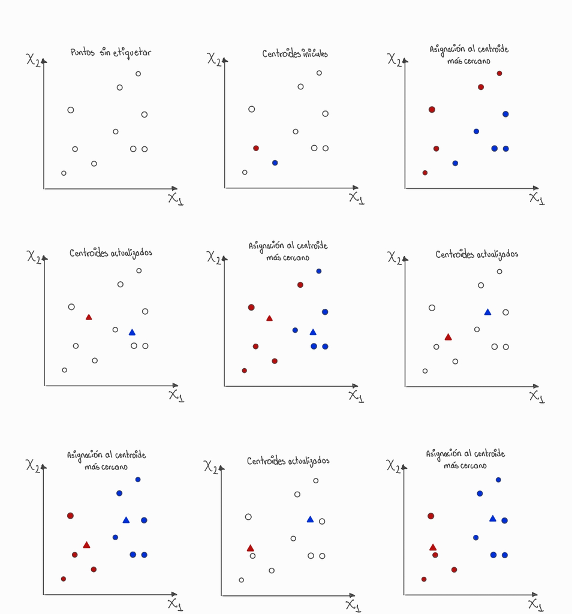

### Algoritmo $k$-medias

- Se prefiere trabajar con las variables cuantitativas estandarizadas
- La forma común de escoger los centroides iniciales consiste en escoger de forma completamente al azar $k$ observaciones del conjunto de datos
- Se calculan los centroides como el vector de promedios (variables cuantitativas), el vector de modas (variables cualitativas) o el vector de promedios y modas (mixtura de variables)

### Algoritmo $k$-medias

- En el caso de variables cuantitativas se emplea como medida de distancia la distancia euclidiana
  $$d_{\boldsymbol{x}_i,\boldsymbol{c}_l} = \left\Vert\boldsymbol{x}_i-\boldsymbol{c}_l\right\Vert_2,$$
- En el caso de variables cualitativas se emplea
  $$d_{\boldsymbol{x}_i,\boldsymbol{c}_l} = \sum^p_{j=1}I\left\{x_{ij}\neq \boldsymbol{c}_{lj}\right\},$$
  que genera el método de $k$-modas

### Algoritmo $k$-medias

- Para la mixtura de variables se emplea el método de $k$-prototipos, el cuál se basa en la distancia

  $$d(\boldsymbol{x}_i,\boldsymbol{c}_l) = \left\Vert \boldsymbol{x}^{(num)}_i-\boldsymbol{c}^{(num)}_l \right\Vert_2^2
  + \gamma
  \sum_{j=1}^{p_2}
  I\left\{x^{(cat)}_{ij}\ne c^{(cat)}_{lj}\right\}$$

  con $\gamma$ un parámetro de ajuste que equilibra la contribución de las distancias numéricas y categóricas, y puede ser calculado mediante optimización.

### Algoritmo $k$-medias

El orden en el que se se llevan a cabo la asignación de los individuos a los centroides iniciales y el cálculo de los nuevos centroides generan diferentes algoritmos del tipo $k$-medias conocidos:

- El algoritmo de Lloyd inicia con $k$ centroides, asigna cada individuo al centroide más cercano, recalcula los centroides y repite el proceso hasta alcanzar el criterio de parada.
- El algoritmo de MacQueen asigna los individuos al centroide más cercano y actualiza los centroides durante el proceso de asignación.
- El algoritmo de Hartigan-Wong inicia con una partición en $k$ grupos y evalúa transferencias de individuos entre grupos, aceptando los cambios que reducen la suma de cuadrados intra-grupo.

### Agrupamiento $k$-medias

*Ventajas*:

- Son conceptualmente simples y fáciles de interpretar.
- Su implementación suele ser rápida y escalable.
- Producen una partición directa de los datos en $k$ grupos.
- Cada grupo queda resumido por un representante, lo que facilita su descripción.

### Agrupamiento $k$-medias

*Desventajas*:

- Requieren fijar previamente el número de grupos.
- Son sensibles a la inicialización y pueden converger a soluciones locales.
- Son sensibles a valores atípicos y observaciones extremas.
- Su desempeño depende de la medida de disimilitud y de la escala de las variables.
- Tienden a funcionar mejor cuando los grupos son relativamente compactos; pueden fallar con formas complejas o tamaños muy desiguales.
- En datos mixtos, la ponderación entre parte numérica y categórica no siempre es trivial.

### Algoritmo $hk$-means

- Es un procedimiento híbrido de agrupamiento que combina el agrupamiento jerárquico con k-means. Su idea es usar el método jerárquico para obtener una partición inicial estructurada y, a partir de ella, calcular centroides iniciales más informados que los elegidos aleatoriamente. Luego, sobre esos centroides, se ejecuta k-means para refinar la partición mediante reasignaciones iterativas de las observaciones.
- En términos operativos, primero se construye un dendrograma, luego se corta en $k$ grupos, se calculan las medias de esos grupos como centroides iniciales y finalmente se aplica k-means. Por tanto, la solución final no coincide necesariamente con la partición jerárquica inicial, ya que durante la fase de k-means los individuos pueden cambiar de grupo.
- Desde el punto de vista metodológico, hk-means conserva la capacidad exploratoria del agrupamiento jerárquico y aprovecha la capacidad de optimización local de k-means. Su principal utilidad es reducir la dependencia de una inicialización aleatoria y mejorar la estabilidad de la partición final cuando se trabaja con un número de grupos $k$ previamente fijado.

### Algoritmo $k$-medoides

- Es un método de partición que, al igual que k-means, busca dividir los datos en $k$ grupos. La diferencia fundamental es que cada grupo se representa por un medoide, es decir, una observación real del conjunto de datos que actúa como elemento central del grupo. La asignación de las observaciones se realiza al medoide más cercano según una medida de disimilitud o distancia previamente definida.
- Su objetivo es encontrar el conjunto de $k$ medoides que minimiza la disimilitud total intra-grupo, usualmente expresada como la suma de las distancias entre cada observación y el medoide de su grupo. A diferencia de k-means, no utiliza centroides calculados como promedios, por lo que puede aplicarse con distancias no euclidianas y resulta más robusto frente a valores atípicos.
- En términos operativos, el algoritmo selecciona inicialmente $k$ observaciones como medoides, asigna cada individuo al medoide más cercano y luego evalúa reemplazos de medoides para mejorar la partición. Este proceso se repite hasta que no se logra reducir la disimilitud total.

### Agrupamiento difuso

- Algoritmo de agrupamiento que permite que los individuos pertenezcan a múltiples grupos de manera simultánea
- A cada individuo se le asigna un grado de pertenencia a cada grupo (valores entre 0 y 1).
- Contrasta con el agrupamiento tradicional, donde cada individuo pertenece exclusivamente a un único grupo.

### Fuzzy k-means

El algoritmo más común de agrupamiento difuso es el *Fuzzy k-means*, que minimiza una función objetivo
$$obj = \sum_{i=1}^{n}\sum_{l=1}^{k} u_{il}^{m} d_{il}^{2}$$
que incorpora grados de pertenencia difusos
$$u_{il} = \frac{1}{\sum_{s=1}^k \left(\frac{d_{il}}{d_{is}}\right)^{2/(m-1)}}, \quad 0\le u_{il}\le 1,$$

para $i=1,2,...,n$, $l=1,2,...,k$ y $\sum_{l=1}^k u_{il} = 1$, para todo $i$, y $d_{il}$ corresponde a la distancia entre el individuo $i$ y el centroide del grupo $l$.

### Fuzzy k-means

El algoritmo consiste en aplicar un algoritmo de $k$- medias, en donde en cada iteración se asigna el individuo al grupo con mayor grado de pertenencia y cuyos centroides deben ser actualizados de la forma
$$c_l = \frac{\sum_{i=1}^n u_{il}^m \boldsymbol{x}_i}{\sum_{i=1}^n u_{il}^m}.$$
La elección del parámetro $m$ depende del nivel de solapamiento o difusidad entre los grupos.

- Si $m=1$ el algoritmo equivale al k-means y si $m>1$ significa mayor solapamiento entre grupos.
- Si $m\rightarrow \infty$ todos los datos pertenecen por igual a todos los grupos.
- El rango de valores comúnmente utilizado para $m$ está entre 1.5 y 3, aunque se pueden utilizar métodos de optimización para encontrar el valor más adecuado.

### Métodos basados en densidad

- Los métodos de agrupamiento basados en densidad son una clase de algoritmos de aprendizaje no supervisado que identifican grupos distintivos en conjuntos de datos complejos.
- Estos métodos se basan en la idea fundamental de que un grupo, o coglomerado, es una región contigua en el espacio de los datos donde se concentra una alta densidad de puntos (observaciones), separada de otros grupos por áreas de baja densidad.

### Algoritmo DBSCAN

**DBSCAN** (Density Based Spatial Clustering of Applications with Noise)

- Es uno de los métodos más populares de agrupamiento basado en densidad, que a diferencia de los métodos basados en centroides no tiene un número predefinido de grupos.
- El algoritmo está determinado por dos parámetros: un $\epsilon$ que define la distancia máxima a la que se considera que dos puntos están lo suficientemente cerca como para pertenecer al mismo grupo, y un *MinPts* que determina la cantidad mínima de puntos requerida para que se forme un grupo.

### Algoritmo DBSCAN

Conceptos clave:

- $\epsilon$-vecindad de un punto: se define como el conjunto de $N_\epsilon\left(\boldsymbol{p}\right)$ puntos que están a una distancia menor o igual que $\epsilon$ del punto $\boldsymbol{p}$, incluido el propio punto
- *Puntos directamente alcanzables en densidad*: un punto $\boldsymbol{p}$ es directamente alcanzable en densidad desde un punto $\boldsymbol{q}$ si $\boldsymbol{p}$ pertenece a la $\epsilon$-vecindad de $\boldsymbol{q}$ y $N_\epsilon\left(\boldsymbol{q}\right)\ge MinPts$
- *Puntos alcanzables en densidad*: un punto $\boldsymbol{p}$ es alcanzable en densidad desde un punto $\boldsymbol{q}$ si existe una secuencia de puntos $\boldsymbol{p}_1, \boldsymbol{p}_2, ..., \boldsymbol{p}_m$, con $\boldsymbol{p}_1=\boldsymbol{q}$ y $\boldsymbol{p}_m=\boldsymbol{p}$, tal que $\boldsymbol{p}_{i+1}$ es directamente alcanzable en densidad desde $\boldsymbol{p}_{i}$

### Algoritmo DBSCAN

Conceptos clave:

- *Puntos núcleo*: un punto $\boldsymbol{p}$ es un punto núcleo si al menos $MinPts$ puntos están a una distancia menor o igual que $\epsilon$ de $\boldsymbol{p}$, esto es $N_\epsilon\left(\boldsymbol{p}\right)\ge MinPts$
- *Puntos borde*: un punto $\boldsymbol{p}$ es un punto borde si no es un punto núcleo pero se encuentra dentro de la $\epsilon$-vecindad de un punto núcleo
- *Puntos ruido*: un punto es ruido si no es alcanzable en densidad desde cualquier otro punto

### Algoritmo DBSCAN

**Algoritmo**:

1. Definir los parámetros $\epsilon$ y *MinPts*
2. Encontrar los puntos en la $\epsilon$-vecindad de cada punto e identificar los puntos núcleo, borde y ruido.
3. Seleccionar un punto núcleo, no visitado antes, de forma aleatoria y crear un nuevo cluster agregando todos los puntos núcleo directamente alcanzables al nuevo cluster y marcarlos como visitados. Continuar agregando los puntos núcleo alcanzables al nuevo cluster hasta que no haya nuevos puntos núcleo alcanzables no visitados.
4. Repetir el paso 3 hasta que se hayan visitado todos los puntos núcleo.
5. Asignar los puntos borde al grupo al que pertenece el punto núcleo en la $\epsilon$-vecindad del punto borde.

### Algoritmo DBSCAN

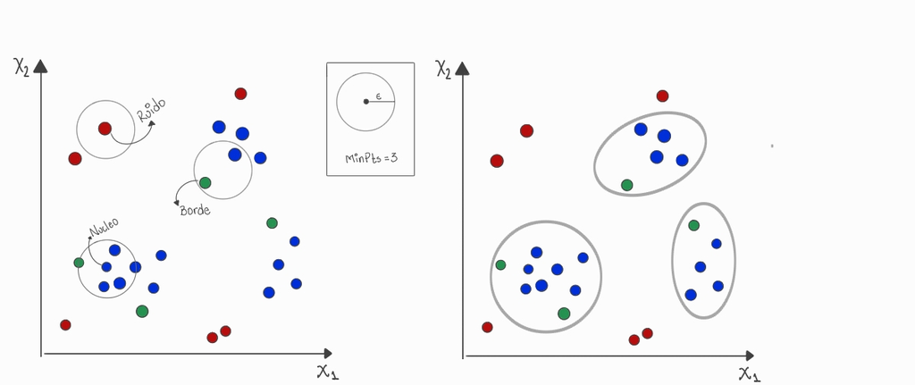

### Algoritmo DBSCAN

- Índice DBCV (*Density-Based Clustering Validation Index*): evalúa agrupamientos basados en densidad, especialmente cuando los grupos pueden tener formas arbitrarias y estar separados por regiones de baja densidad.
- Su objetivo es comparar separación entre grupos frente a dispersión interna de cada grupo.
- Para un grupo $C_i$ se define
  $$V(C_i) = \frac{DSPC(C_i)-DSC(C_i)}{\max\{DSPC(C_i),DSC(C_i)\}},\quad -1 \leq V(C_i) \leq 1$$
  donde $DSC(C_i)$ mide la dispersión interna de densidad del grupo, y $DSPC(C_i)$ mide la separación de densidad entre $C_i$ y los demás grupos.

### Algoritmo DBSCAN

- El índice DBCV global se calcula como:
  $$DBCV = \sum_{i=1}^{k} \frac{|C_i|}{n}V(C_i),\quad -1 \leq DBCV \leq 1$$
  Es decir, es un promedio ponderado de la validez de cada grupo, usando como peso el tamaño relativo del grupo.
- Valores cercanos a 1 indican grupos densos y bien separados; cercanos a 0, estructura débil o poco clara; y cercanos a -1, mal definidos o artificiales.

### Métodos basados en mezclas de distribuciones

- Los métodos de agrupamiento basados en mezclas de distribuciones, son un enfoque probabilístico que asume que los datos observados se generan a partir de una mezcla o combinación de distribuciones de probabilidad subyacentes.
- Cada componente de la mezcla representa un grupo, y el objetivo es estimar los parámetros de estas distribuciones junto con las probabilidades de pertenencia de cada individuo a los grupos.

### Métodos basados en mezclas de distribuciones

Si tenemos $k$ distribuciones, cada una con distribución $f_l\left(\boldsymbol{x} \mid \boldsymbol{\theta}_l\right)$, donde $\boldsymbol{\theta}_l$ son los parámetros de la distribución de la población $l$-ésima, la fdp global de los datos se modela como una combinación convexa de estas distribuciones:
$$f_{\boldsymbol{X}}\left(\boldsymbol{x} \mid \boldsymbol{\theta}\right) = \sum_{l=1}^k \pi_l f_l \left(\boldsymbol{x} \mid \boldsymbol{\theta}_l\right),$$

### Mezclas gaussianas

El método de **mezclas gaussianas** es un agrupamiento probabilístico que supone que la población está formada por $k$ subpoblaciones latentes. Cada una de ellas se modela mediante una distribución normal multivariada. En consecuencia, la distribución total de una observación se representa como una combinación ponderada de varias densidades gaussianas.

### Mezclas gaussianas

Si $\mathbf{x}_1,\dots,\mathbf{x}_n$ son observaciones en $\mathbb{R}^p$, el modelo plantea que la densidad marginal de $\mathbf{x}_i$ es

$$f(\mathbf{x}_i)=\sum_{l=1}^{k}\pi_l\,\phi(\mathbf{x}_i;\boldsymbol{\mu}_l,\boldsymbol{\Sigma}_l),$$

donde $\pi_l>0$, $\sum_{l=1}^{k}\pi_l=1$, y $\phi(\mathbf{x};\boldsymbol{\mu},\boldsymbol{\Sigma})$ es la densidad normal multivariada

$$\phi(\mathbf{x};\boldsymbol{\mu},\boldsymbol{\Sigma})=\frac{1}{(2\pi)^{p/2}|\boldsymbol{\Sigma}|^{1/2}}
\exp\!\left[
-\frac{1}{2}
(\mathbf{x}-\boldsymbol{\mu})^\top
\boldsymbol{\Sigma}^{-1}
(\mathbf{x}-\boldsymbol{\mu})
\right].$$

### Mezclas gaussianas

[interactive chart not shown]

### Mezclas gaussianas

El modelo introduce una variable no observada que indica de qué componente proviene cada observación:

$$z_{il}=
\begin{cases}
1, & \text{si la observación } i \text{ proviene del componente } l, \\
0, & \text{en otro caso.}
\end{cases}$$

Así,

$$P(z_{il}=1)=\pi_l.$$

La pertenencia real a los componentes no se observa, por lo que el problema consiste en estimarla conjuntamente con los parámetros del modelo.

### Mezclas gaussianas

Dado que las pertenencias son desconocidas, la verosimilitud observada del modelo es

$$L(\boldsymbol{\theta}) = \prod_{i=1}^{n}\sum_{l=1}^{k}
\pi_l\,\phi(\mathbf{x}_i;\boldsymbol{\mu}_l,\boldsymbol{\Sigma}_l),$$

donde $\boldsymbol{\theta} = \{\pi_1,\dots,\pi_k, \boldsymbol{\mu}_1,\dots,\boldsymbol{\mu}_k, \boldsymbol{\Sigma}_1,\dots,\boldsymbol{\Sigma}_k \}.$

La log-verosimilitud correspondiente es

$$\ell(\boldsymbol{\theta}) = \sum_{i=1}^{n}
\log\left[\sum_{l=1}^{k}\pi_l\,\phi(\mathbf{x}_i;\boldsymbol{\mu}_l,\boldsymbol{\Sigma}_l)\right].$$

Esta expresión no se maximiza fácilmente de forma cerrada debido a la suma dentro del logaritmo. Por ello se emplea el algoritmo EM.

### Mezclas gaussianas

El algoritmo **EM** (*Expectation-Maximization*) alterna entre dos etapas hasta alcanzar convergencia.

- Paso E: en esta etapa se calculan las probabilidades posteriores de pertenencia de cada observación a cada componente. Estas probabilidades, llamadas responsabilidades, están dadas por
  $$\tau_{il} = P(z_{il}=1\mid \mathbf{x}_i) = \frac{
  \pi_l\,\phi(\mathbf{x}_i;\boldsymbol{\mu}_l,\boldsymbol{\Sigma}_l)}{\sum_{h=1}^{k}
  \pi_h\,\phi(\mathbf{x}_i;\boldsymbol{\mu}_h,\boldsymbol{\Sigma}_h)
  }.$$
  Cada $\tau_{il}$ mide qué tan probable es que la observación $i$ pertenezca al grupo $l$, dados los valores actuales de los parámetros.

### Mezclas gaussianas

- Paso M: en esta etapa se actualizan los parámetros del modelo usando las responsabilidades como ponderaciones:
  $$\pi_l^{\text{nuevo}}=\frac{N_l}{n},$$
  $$\boldsymbol{\mu}_l^{\text{nuevo}} = \frac{\sum_{i=1}^{n}\tau_{il}\mathbf{x}_i}{N_l},$$
  $$\boldsymbol{\Sigma}_l^{\text{nuevo}}=\frac{\sum_{i=1}^{n}\tau_{il}(\mathbf{x}_i-\boldsymbol{\mu}_l^{\text{nuevo}})(\mathbf{x}_i-\boldsymbol{\mu}_l^{\text{nuevo}})^\top}{N_l},$$
  con $N_l=\sum_{i=1}^{n}\tau_{il}$.

  Con estos nuevos valores se regresa al paso E, y el proceso se repite hasta que la log-verosimilitud se estabilice.

### Mezclas gaussianas

- Finalmente, cada observación se asigna al grupo con mayor probabilidad posterior:
  $$\widehat{g}_i=\arg\max_{l}\tau_{il}.$$
- Como el número $k$ no suele conocerse, es habitual ajustar varios modelos y elegir el que optimice un criterio de información. Uno de los más usados es el BIC:
  $$\mathrm{BIC}=-2\,\ell(\widehat{\boldsymbol{\theta}})
  +m\log(n),$$
  donde $m$ es el número de parámetros estimados del modelo. Se elige el modelo con menor BIC.

### Medidas de validación

- En clustering, las medidas de validación son criterios cuantitativos utilizados para evaluar la calidad de una partición obtenida mediante un algoritmo de agrupamiento.
- Su función es determinar, desde distintos puntos de vista, si los grupos formados presentan una estructura razonable en los datos; por ejemplo, si son internamente homogéneos, externamente separados, estables ante perturbaciones o concordantes con una clasificación de referencia.
- En consecuencia, estas medidas no “prueban” que exista una única solución verdadera, sino que proporcionan evidencia para comparar particiones, diagnosticar su calidad y apoyar decisiones como la elección del número de clústeres.

### Medidas de validación

**Algunos tipos de medidas de validación**

- Validación interna: Silhouette, Dunn, Calinski–Harabasz (CH), Davies–Bouldin (DB), Connectivity, Gap.
- Medidas de estabilidad: APN (Average Proportion of Non-overlap), FOM (Figure of Merit), Prediction Strength, Bootstrap Jaccard stability
- Validación externa: Adjusted Rand Index (ARI), Normalized Mutual Information (NMI), Variation of Information (VI)

### Medidas de validación interna

**Silhouette**: es el promedio de la silueta de cada individuo
$$\bar{S}=\frac{1}{n}\sum_{i=1}^{n}S(i),\qquad -1\le \bar{S}\le 1,$$
donde
$$S(i)=\frac{b_i-a_i}{\max(b_i,a_i)},\qquad -1\le S(i)\le 1,$$
$$a_i=\frac{1}{n\bigl(\mathcal{C}(i)\bigr)-1}\sum_{\substack{j\in\mathcal{C}(i)\\ j\ne i}}d\left(\boldsymbol{x}_i,\boldsymbol{x}_j\right);\qquad b_i=\min_{\mathcal{C}_{l}\in\mathscr{C}\backslash\mathcal{C}(i)}\left\{ \frac{1}{n\left(\mathcal{C}_{l}\right)}\sum_{j\in\mathcal{C}_{l}}d\left(\boldsymbol{x}_{i},\boldsymbol{x}_{j}\right)\right\},$$
con $i=1,2,\ldots,n$, $\mathscr{C}=\{\mathcal{C}_1,\ldots,\mathcal{C}_k\}$ el conjunto de todos los grupos, $\mathcal{C}(i)$ el grupo que contiene al individuo $i$ y $n\bigl(\mathcal{C}(i)\bigr)$ el número de elementos en $\mathcal{C}(i)$. **Debe ser maximizada**.

### Medidas de validación interna

**Dunn**: es el cociente entre la distancia más pequeña entre las observaciones que no están en el mismo grupo y la distancia más grande dentro del grupo:
$$D\left(\mathscr{C}\right)=\frac{{\displaystyle \min_{\substack{\mathcal{C}_{l},\mathcal{C}_{m}\in\mathscr{C}\\ l\ne m}}}\left\{ {\displaystyle \min_{i\in\mathcal{C}_{l},j\in\mathcal{C}_{m}}}d\left(\boldsymbol{x}_{i},\boldsymbol{x}_{j}\right)\right\} }{{\displaystyle \max_{\mathcal{C}_{l}\in\mathscr{C}}}\left\{ {\displaystyle \max_{i,j\in\mathcal{C}_{l}}}d\left(\boldsymbol{x}_{i},\boldsymbol{x}_{j}\right)\right\} },\qquad 0\le D\left(\mathscr{C}\right)<\infty.$$
**Debe ser maximizada**.

### Medidas de validación interna

**Calinski-Harabasz (CH)**: compara la variabilidad **entre grupos** con la variabilidad **dentro de los grupos**. Se define como
$$CH\left(\mathscr{C}\right)=
\frac{\displaystyle \frac{1}{k-1}\sum_{l=1}^{k}n_{l}\left\|\bar{\boldsymbol{x}}_{l}-\bar{\boldsymbol{x}}\right\|^{2}}
{\displaystyle \frac{1}{n-k}\sum_{l=1}^{k}\sum_{i\in\mathcal{C}_{l}}\left\|\boldsymbol{x}_{i}-\bar{\boldsymbol{x}}_{l}\right\|^{2}},
\qquad k\geq 2,$$
donde $n_{l}$ es el tamaño del grupo $\mathcal{C}_{l}$, $\bar{\boldsymbol{x}}_{l}$ es el centroide del grupo $l$ y $\bar{\boldsymbol{x}}$ es el centroide global. El numerador representa la dispersión de los centroides de los grupos respecto al centroide global, mientras que el denominador representa la dispersión de las observaciones alrededor del centroide de su propio grupo. En consecuencia, valores altos de $CH\left(\mathscr{C}\right)$ indican una partición con grupos bien separados y, al mismo tiempo, compactos internamente. **Debe ser maximizada**.

### Medidas de validación interna

**Davies-Bouldin (DB)**: para cada grupo compara su dispersión interna con su separación respecto de los demás grupos. Se define como
$$DB\left(\mathscr{C}\right)=\frac{1}{k}\sum_{l=1}^{k}\max_{m\neq l}R_{lm}.$$
donde
$$S_{l}=\frac{1}{n_{l}}\sum_{i\in\mathcal{C}_{l}}\left\|\boldsymbol{x}_{i}-\bar{\boldsymbol{x}}_{l}\right\|,\qquad
M_{lm}=\left\|\bar{\boldsymbol{x}}_{l}-\bar{\boldsymbol{x}}_{m}\right\|,$$
$$R_{lm}=\frac{S_{l}+S_{m}}{M_{lm}},\quad l\neq m.$$
Valores pequeños indican grupos más compactos y mejor separados. **Debe ser minimizada**.

### Medidas de validación interna

**Connectivity**: se define como
$$\mathrm{Conn}\left(\mathscr{C}\right)=\sum_{i=1}^{n}\sum_{j=1}^{L}x_{i,v_{i(j)}},\qquad 0\le \mathrm{Conn}\left(\mathscr{C}\right)<\infty,$$
donde $L$ es el número de vecinos que contribuyen a la medida de conectividad, $v_{i(j)}$ es el $j$-ésimo vecino más cercano de la observación $i$, y
$$x_{i,v_{i(j)}}=\begin{cases}
0, & \text{si } i \text{ y } v_{i(j)} \text{ están en el mismo grupo},\\
\frac{1}{j}, & \text{en otro caso.}
\end{cases}$$
**Debe ser minimizada**.

### Medidas de validación interna

**Gap statistic**: compara la dispersión intra-grupo observada con la que se esperaría si los datos no tuvieran estructura de agrupamiento. Se define como
$$\mathrm{Gap}(k)=\mathbb{E}^{*}\!\left[\log\left(W_{k}\right)\right]-\log\left(W_{k}\right),$$
donde
$$W_{k}=\sum_{l=1}^{k}\frac{1}{2n_{l}}\sum_{i,j\in\mathcal{C}_{l}}d^2\left(\boldsymbol{x}_{i},\boldsymbol{x}_{j}\right),$$
es una medida de dispersión intra-grupo, y $\mathbb{E}^{*}$ denota la esperanza bajo una distribución de referencia sin clústeres, usualmente aproximada por simulación Monte Carlo. Para seleccionar el número de grupos, suele elegirse el menor $k$ tal que
$$\mathrm{Gap}(k)\geq \mathrm{Gap}(k+1)-s_{k+1},$$
donde $s_{k+1}$ es un ajuste por error estándar obtenido a partir de las simulaciones. **Debe ser maximizada**.

### Medidas de estabilidad

**APN (Average Proportion of Non-overlap)**: se calcula como
$$APN=\frac{1}{np}\sum_{i=1}^{n}\sum_{s=1}^{p}\left(1-\frac{n\left(\mathcal{C}_{i}^{(s)}\cap\mathcal{C}_{i}\right)}{n\left(\mathcal{C}_{i}\right)}\right),\qquad 0\le APN\le 1,$$
donde $\mathcal{C}_{i}$ representa el grupo que contiene a la observación $i$ en el agrupamiento original, y $\mathcal{C}_{i}^{(s)}$ representa el grupo que contiene a la observación $i$ cuando el agrupamiento se basa en los datos con la columna $s$ removida, con $s=1,2,\ldots,p$. **Debe ser minimizada**.

### Medidas de estabilidad

**FOM (Figure of Merit)**: se calcula como
$$FOM=\sqrt{\frac{n}{n-k}}\frac{1}{p}\sum_{s=1}^{p}FOM(s),$$
donde
$$FOM(s)=\sqrt{\frac{1}{n}\sum_{l=1}^{k}\sum_{i\in\mathcal{C}_{l}^{(s)}}d\left(x_{i,s},\bar{x}_{\mathcal{C}_{l}^{(s)}}\right)}\,,\qquad 0\le FOM(s)<\infty,$$
con $x_{i,s}$ el valor de la observación $i$ en la columna $s$, $\bar{x}_{\mathcal{C}_{l}^{(s)}}$ el promedio de la columna $s$ en el grupo $\mathcal{C}_{l}^{(s)}$, y $\mathcal{C}_{l}^{(s)}$ el grupo $l$ obtenido al realizar el agrupamiento con la columna $s$ removida. **Debe ser minimizada**.

### Medidas de estabilidad

**Prediction Strength**: mide la estabilidad predictiva de una partición. Para ello, se divide aleatoriamente la muestra en dos mitades $A$ y $B$, se obtiene una partición en $k$ grupos en cada mitad y luego se evalúa, para cada grupo de una mitad, qué proporción de pares de observaciones que quedaron juntas siguen siendo asignadas conjuntamente cuando se clasifican con base en la partición obtenida en la otra mitad. Para una partición de $A$ en $k$ grupos, se define
$$PS_{A\to B}(k)=\min_{1\le l\le k}\left\{\frac{1}{n_l^{A}\left(n_l^{A}-1\right)}\sum_{\substack{i\neq j\\ i,j\in\mathcal{C}_{l}^{A}}}I_{ij}^{A\to B}\right\},$$
donde
$$I_{ij}^{A\to B}=
\begin{cases}
1, & \text{si } i \text{ y } j \text{ son asignadas al mismo grupo usando la partición de } B,\\
0, & \text{en otro caso.}
\end{cases}$$

### Medidas de estabilidad

De forma análoga se calcula $PS_{B\to A}(k)$, y si se repite este procedimiento en $M$ particiones aleatorias de la muestra, la estadística final se obtiene como
$$PS(k)=\frac{1}{2M}\sum_{r=1}^{M}\left[PS_{A\to B}^{(r)}(k)+PS_{B\to A}^{(r)}(k)\right].$$
Valores altos indican que la estructura en $k$ grupos es reproducible bajo particiones de la muestra. Para seleccionar el número de grupos suele elegirse el mayor $k$ tal que $PS(k)$ supere un umbral, frecuentemente entre $0.8$ y $0.9$. **Debe ser maximizada**.

### Medidas de estabilidad

**Bootstrap Jaccard stability**: mide la estabilidad de cada grupo comparándolo con el grupo más similar obtenido en muestras bootstrap. Para el grupo $\mathcal{C}_{l}$ y la réplica bootstrap $b$, se define
$$J_{l}^{(b)}=\max_{m}\frac{n\left(\mathcal{C}_{l}\cap\mathcal{C}_{m}^{*(b)}\right)}{n\left(\mathcal{C}_{l}\cup\mathcal{C}_{m}^{*(b)}\right)},$$
donde $\mathcal{C}_{m}^{*(b)}$ representa el grupo $m$ obtenido en la réplica bootstrap $b$. La estabilidad bootstrap del grupo $\mathcal{C}_{l}$ se resume mediante
$$\bar{J}_{l}=\frac{1}{B}\sum_{b=1}^{B}J_{l}^{(b)},$$

### Medidas de estabilidad

Si se desea una medida global, puede promediarse sobre los $k$ grupos:
$$\bar{J}=\frac{1}{k}\sum_{l=1}^{k}\bar{J}_{l}.$$
Valores altos indican que los grupos originales se reproducen de forma consistente bajo remuestreo bootstrap. **Debe ser maximizada**.

### Medidas de validación externa

**Adjusted Rand Index (ARI)**: mide el grado de concordancia entre dos particiones de las mismas $n$ observaciones, corrigiendo por el acuerdo esperado por azar. Sean $\mathscr{C}=\{\mathcal{C}_{1},\ldots,\mathcal{C}_{k}\}$ y $\mathscr{G}=\{\mathcal{G}_{1},\ldots,\mathcal{G}_{r}\}$ dos particiones, el índice se define como
$$ARI=\frac{\sum_{l=1}^{k}\sum_{m=1}^{r}\binom{n_{lm}}{2}- \sum_{l=1}^{k}\binom{a_{l}}{2}\sum_{m=1}^{r}\binom{b_{m}}{2} /\binom{n}{2}}{ \frac{1}{2}\left[\sum_{l=1}^{k}\binom{a_{l}}{2}+\sum_{m=1}^{r}\binom{b_{m}}{2}\right]-\sum_{l=1}^{k}\binom{a_{l}}{2}\sum_{m=1}^{r}\binom{b_{m}}{2}/\binom{n}{2}},$$
donde $n_{lm}=n\left(\mathcal{C}_{l}\cap\mathcal{G}_{m}\right)$ es el número de observaciones comunes a los grupos $\mathcal{C}_{l}$ y $\mathcal{G}_{m}$, y $a_{l}=\sum_{m=1}^{r}n_{lm}$ y $b_{m}=\sum_{l=1}^{k}n_{lm}$.

Valores cercanos a $1$ indican alta concordancia entre ambas particiones, un valor cercano a $0$ indica acuerdo compatible con azar y valores negativos indican concordancia menor que la esperada aleatoriamente. **Debe ser maximizada**.

### Medidas de validación externa

**NMI (Normalized Mutual Information)**: mide la cantidad de información compartida entre dos particiones, normalizada para tomar valores entre $0$ y $1$. Usando la misma tabla de contingencia del ARI, sea
$$p_{lm}=\frac{n_{lm}}{n},\qquad p_{l\cdot}=\frac{a_l}{n},\qquad p_{\cdot m}=\frac{b_m}{n}.$$
La información mutua entre ambas particiones se define como
$$I\left(\mathscr{C},\mathscr{G}\right)=\sum_{l=1}^{k}\sum_{m=1}^{r}p_{lm}\log\left(\frac{p_{lm}}{p_{l\cdot}p_{\cdot m}}\right),$$
mientras que sus entropías son
$$H\left(\mathscr{C}\right)=-\sum_{l=1}^{k}p_{l\cdot}\log\left(p_{l\cdot}\right),\qquad
H\left(\mathscr{G}\right)=-\sum_{m=1}^{r}p_{\cdot m}\log\left(p_{\cdot m}\right).$$

### Medidas de validación externa

Una normalización frecuente es
$$NMI=\frac{2\,I\left(\mathscr{C},\mathscr{G}\right)}{H\left(\mathscr{C}\right)+H\left(\mathscr{G}\right)},\qquad 0\le NMI\le 1.$$
Valores cercanos a $1$ indican alta concordancia entre ambas particiones, mientras que valores cercanos a $0$ indican baja información compartida. **Debe ser maximizada**.

### Medidas de validación externa

**VI (Variation of Information)**: mide la discrepancia entre dos particiones a partir de la información que no comparten. Usando la misma notación del ARI y la NMI, se define como
$$VI\left(\mathscr{C},\mathscr{G}\right)=H\left(\mathscr{C}\right)+H\left(\mathscr{G}\right)-2I\left(\mathscr{C},\mathscr{G}\right),$$
donde
$$H\left(\mathscr{C}\right)=-\sum_{l=1}^{k}p_{l\cdot}\log\left(p_{l\cdot}\right),\qquad
H\left(\mathscr{G}\right)=-\sum_{m=1}^{r}p_{\cdot m}\log\left(p_{\cdot m}\right),$$
$$I\left(\mathscr{C},\mathscr{G}\right)=\sum_{l=1}^{k}\sum_{m=1}^{r}p_{lm}\log\left(\frac{p_{lm}}{p_{l\cdot}p_{\cdot m}}\right),$$
con $p_{lm}=n_{lm}/n$, $p_{l\cdot}=a_l/n$ y $p_{\cdot m}=b_m/n$.

Valores pequeños indican mayor concordancia entre ambas particiones, mientras que valores grandes indican mayor discrepancia. **Debe ser minimizada**.

### Medidas de validación

**En resumen**:

- Silhouette: mide qué tan bien asignada está cada observación a su grupo frente al grupo alternativo más cercano.
- Dunn: mide la razón entre separación mínima entre grupos y dispersión máxima dentro de los grupos.
- Calinski-Harabasz (CH): evalúa la partición comparando la variabilidad entre grupos con la variabilidad dentro de los grupos.
- Davies-Bouldin (DB): cuantifica qué tan similares son los grupos entre sí en términos de dispersión interna y distancia entre centroides.
- Connectivity: evalúa si observaciones vecinas en el espacio de datos permanecen juntas en la partición obtenida.
- Gap statistic: compara la compactación observada con la esperada bajo una referencia sin estructura de grupos para ayudar a elegir $k$.

### Medidas de validación

- APN: mide cuánto cambia la pertenencia de las observaciones a los grupos al eliminar una variable.
- FOM: evalúa qué tan bien la estructura de grupos predice la variable omitida al recalcular el agrupamiento sin ella.
- Prediction Strength: mide la reproducibilidad de una partición en $k$ grupos al dividir la muestra y contrastar las asignaciones obtenidas.
- Bootstrap Jaccard stability: cuantifica qué tan estable es cada grupo al compararlo con sus réplicas obtenidas por remuestreo bootstrap.
- Adjusted Rand Index (ARI): mide la concordancia entre dos particiones corrigiendo el acuerdo esperado por azar.
- NMI (Normalized Mutual Information): mide la cantidad de información compartida entre dos particiones.
- VI (Variation of Information): mide la discrepancia entre dos particiones a partir de la información que no comparten.

### Datos faltantes

Existen diferentes alternativas para el tratamiento de datos faltantes en análisis de conglomerados.

- Una alternativa es hacer el cálculo de la matriz de disimilitudes mediante Gower y emplear aquellos métodos de agrupamiento basados en esta matriz, como es el caso de los métodos jerárquicos, el k-medoides o el dbscan.
- Otra alternativa es el método ClustImpute, el cual es un algoritmo de k-medias con imputación estocástica iterativa por donantes dentro de grupos.